# m&m’s exercise: Posterior Predictive Checking

Prof. Gwen Eadie

05/07/2025

### Reminder of set-up for m&m’s exercise

$$P(\theta|y) =
\frac{P(y|\theta)P(\theta)}{P(y)}$$

We defined:

- $\theta$ as the percentage of blue candies made at the factory
- $y$ as the number of blue candies observed in our data

The likelihood for our model was the binomial distribution with parameter $\theta$:

$$p(y|\theta) \propto
\theta^{y}(1-\theta)^{n-y}.$$

This is our likelihood for $y$ blue candies, given the percentage $\theta$ produced at the factory.

We used the conjugate prior to the binomial distribution — the beta distribution — to quantify your prior information on the percentage $\theta$ of blue candies made at the factory:
$$p(\theta) \propto
\theta^{\alpha-1}(1-\theta)^{\beta-1}$$
We chose some hyperparameter values

```r
# my hyperprior parameters for alpha and beta
mya = 1.7
myb = 10
```

Next, we collected our data, both individually, and as a class.

```r
# record your data before eating it!

# total number of trials
n = 10

########### PLAIN ##################
y = 1 # number of blue
nred = 3
norange = 5
nyellow = 2
ngreen = 3
nbrown = 1

# class data, number of successes from each bag
mydata = c(3,3,4,5,6,2,2,8,1, 0, 2,4,1,5,2,5)

# number of bags in the class
nbags = length(mydata)
```

We calculated the posterior given your data and your prior distribution, and plotted it.

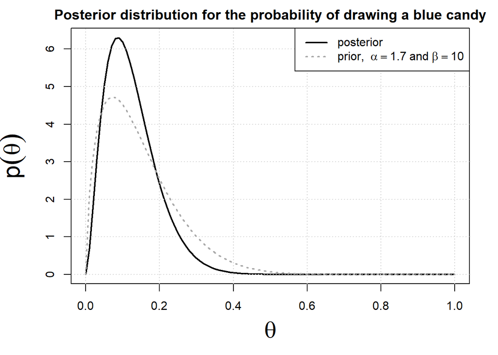

```r
# set margins
par( mar = c(5,5,2,2))

# plot the posterior distribution
curve( dbeta( x, shape1 = (y + mya), shape2 = (n-y+myb)),
      xlab = expression(theta), ylab = expression(p(theta)) ,
      main = "Posterior distribution for the probability of drawing a blue candy",
      cex.lab=2, lwd=2)

grid()


# add the prior distribution to the plot, to compare
curve(dbeta(x, shape1 = mya, shape2 = myb),
      lwd=2, lty=3, add=TRUE, col="darkgrey")


# add a legend
legend("topright", legend = c("posterior",
                              as.expression(bquote("prior, "~alpha == .(mya)~"and"~beta == .(myb))) ),
   lty=c(1,3), lwd=2, col=c("black", "darkgrey"))
```

### Exercise

Estimate the posterior predictive distribution and compare it to the distribution of successes (blue m&m’s) from the class

To calculate the posterior predictive distribution, follow these steps:

- draw a random value of $\theta$ from the posterior
- draw a $y$ (number of blue m&m’s) from the likelihood (binomial distribution) given that value of $\theta$
- Repeat this many times.

```r
nsims=500
yfuture = vector(length = nsims)

# draw a random theta
thetatemp <- rbeta( n = nsims, shape1 = (y + mya), shape2 = (n-y+myb))

# draw a random y (number of blues)
yfuture <- rbinom(n = nsims, size = 15, prob=thetatemp)
```

Next, compare the predicted distribution of successes (number of blues) to the distribution of successes for the whole class.

[figure not shown]

```r
# plot to compare
hist(yfuture, probability = TRUE, breaks=seq(-0.5,15.5, by=1))
hist(mydata, probability = TRUE, breaks=seq(-0.5,15.5, by=1), add=TRUE, col=rgb(0,0.3,0.6,0.6))
legend("topright", legend = c("class data", "posterior predicitive"), col=c("grey", rgb(0,0.3,0.6,0.6)), lty=1, lwd=5)

box()
```